# stoRy time with shiny and quarto

A story written by you & AI

I am learning English

Once upon a time, in a small village surrounded by rolling hills and towering mountains that stood like giants in the distance, there lived a young boy named Timmy who had a big dream to become a brave knight just like his hero, Sir Edward, who had saved the kingdom from the evil dragon many years ago.

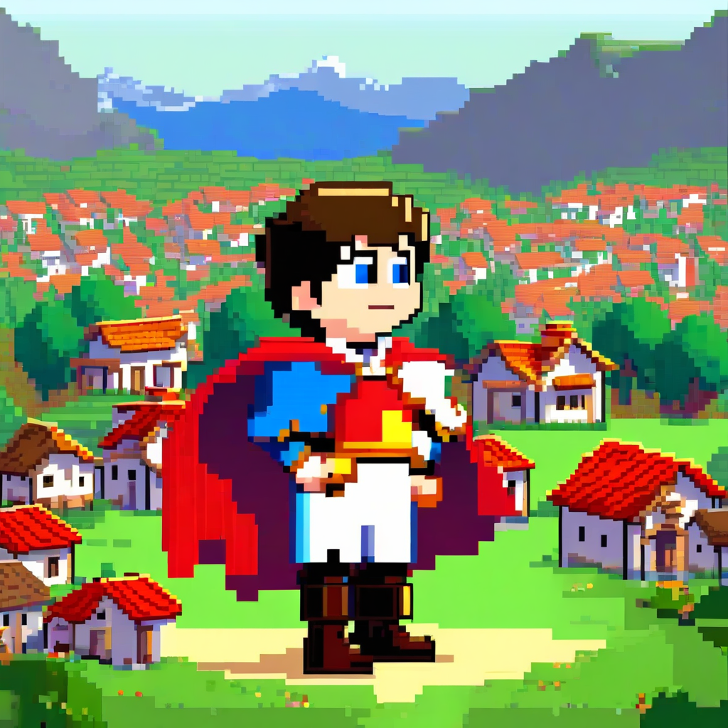

Timmy’s village was known for its beautiful gardens filled with the most vibrant flowers that bloomed in every color of the rainbow, and the air was sweet with the scent of honey and fresh bread that wafted from the village bakery every morning.

[figure not shown]

Timmy spent most of his days playing with his best friend, a clever and quick-witted rabbit named Rosie, who was known for her incredible speed and agility, and together they would explore the woods, discovering hidden streams and secret meadows that were home to a variety of exotic birds and animals.

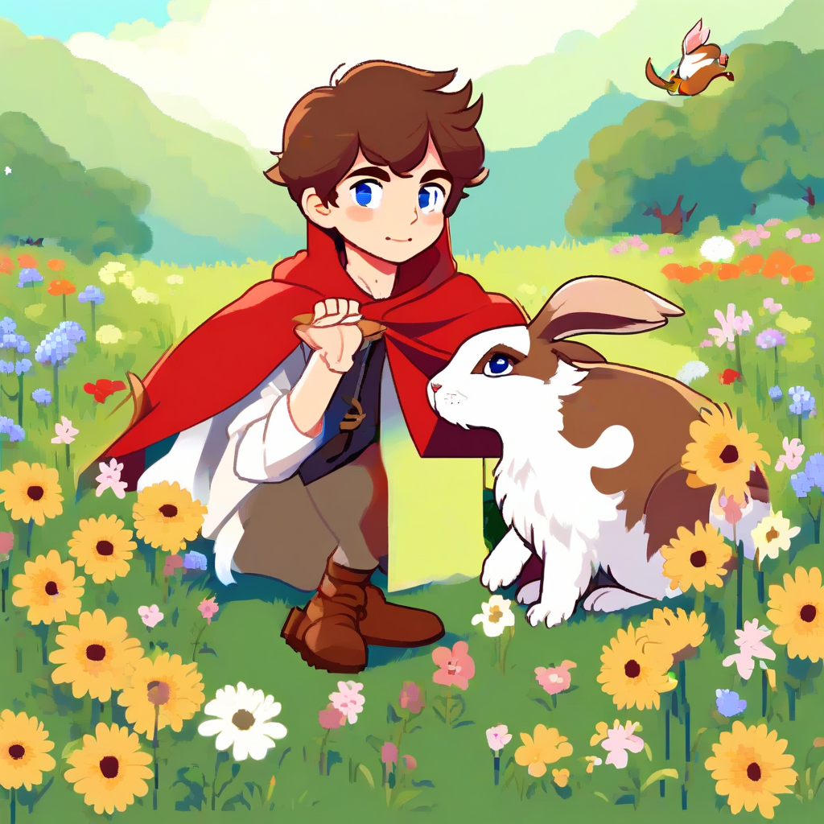

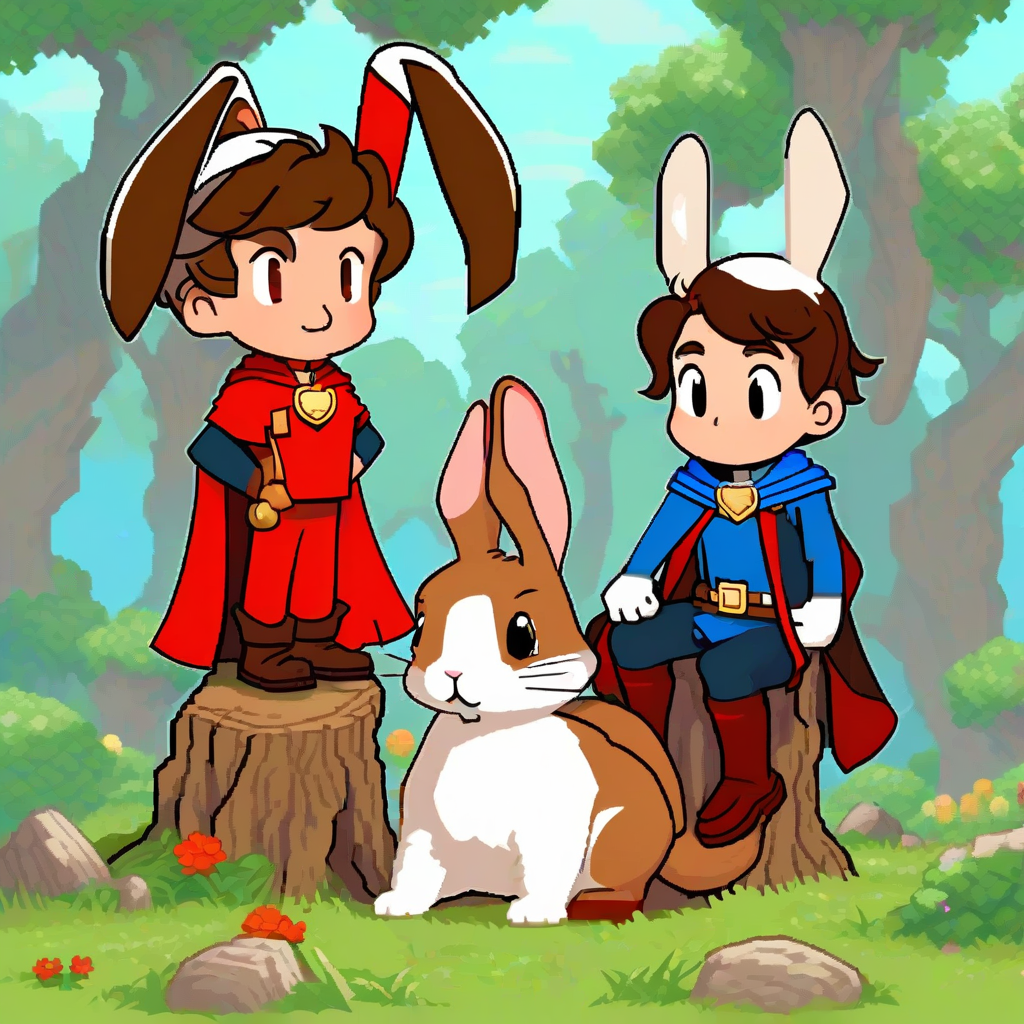

One day, while out on an adventure, Timmy and Rosie stumbled upon a mysterious map that hinted at the location of a legendary treasure hidden deep within the heart of the forest, and with determination in his heart and a sense of excitement in his soul, Timmy decided to embark on a quest to find the treasure before anyone else did.

[figure not shown]

With Rosie by his side, Timmy bravely navigated through the dense forest, facing many obstacles and challenges along the way, but in the end, they discovered a chest filled with glittering gold coins and precious jewels, and they returned to the village as heroes, celebrated by the villagers for their bravery and cunning.